# 红酒质量分析

研究目的：探寻哪个化学成分影响红葡萄酒的质量

# 数据结构概览

```
## 'data.frame':    1599 obs. of  13 variables:
##  $ X                   : int  1 2 3 4 5 6 7 8 9 10 ...
##  $ fixed.acidity       : num  7.4 7.8 7.8 11.2 7.4 7.4 7.9 7.3 7.8 7.5 ...
##  $ volatile.acidity    : num  0.7 0.88 0.76 0.28 0.7 0.66 0.6 0.65 0.58 0.5 ...
##  $ citric.acid         : num  0 0 0.04 0.56 0 0 0.06 0 0.02 0.36 ...
##  $ residual.sugar      : num  1.9 2.6 2.3 1.9 1.9 1.8 1.6 1.2 2 6.1 ...
##  $ chlorides           : num  0.076 0.098 0.092 0.075 0.076 0.075 0.069 0.065 0.073 0.071 ...
##  $ free.sulfur.dioxide : num  11 25 15 17 11 13 15 15 9 17 ...
##  $ total.sulfur.dioxide: num  34 67 54 60 34 40 59 21 18 102 ...
##  $ density             : num  0.998 0.997 0.997 0.998 0.998 ...
##  $ pH                  : num  3.51 3.2 3.26 3.16 3.51 3.51 3.3 3.39 3.36 3.35 ...
##  $ sulphates           : num  0.56 0.68 0.65 0.58 0.56 0.56 0.46 0.47 0.57 0.8 ...
##  $ alcohol             : num  9.4 9.8 9.8 9.8 9.4 9.4 9.4 10 9.5 10.5 ...
##  $ quality             : int  5 5 5 6 5 5 5 7 7 5 ...
```

```
##        X          fixed.acidity   volatile.acidity  citric.acid
##  Min.   :   1.0   Min.   : 4.60   Min.   :0.1200   Min.   :0.000
##  1st Qu.: 400.5   1st Qu.: 7.10   1st Qu.:0.3900   1st Qu.:0.090
##  Median : 800.0   Median : 7.90   Median :0.5200   Median :0.260
##  Mean   : 800.0   Mean   : 8.32   Mean   :0.5278   Mean   :0.271
##  3rd Qu.:1199.5   3rd Qu.: 9.20   3rd Qu.:0.6400   3rd Qu.:0.420
##  Max.   :1599.0   Max.   :15.90   Max.   :1.5800   Max.   :1.000
##  residual.sugar     chlorides       free.sulfur.dioxide
##  Min.   : 0.900   Min.   :0.01200   Min.   : 1.00
##  1st Qu.: 1.900   1st Qu.:0.07000   1st Qu.: 7.00
##  Median : 2.200   Median :0.07900   Median :14.00
##  Mean   : 2.539   Mean   :0.08747   Mean   :15.87
##  3rd Qu.: 2.600   3rd Qu.:0.09000   3rd Qu.:21.00
##  Max.   :15.500   Max.   :0.61100   Max.   :72.00
##  total.sulfur.dioxide    density             pH          sulphates
##  Min.   :  6.00       Min.   :0.9901   Min.   :2.740   Min.   :0.3300
##  1st Qu.: 22.00       1st Qu.:0.9956   1st Qu.:3.210   1st Qu.:0.5500
##  Median : 38.00       Median :0.9968   Median :3.310   Median :0.6200
##  Mean   : 46.47       Mean   :0.9967   Mean   :3.311   Mean   :0.6581
##  3rd Qu.: 62.00       3rd Qu.:0.9978   3rd Qu.:3.400   3rd Qu.:0.7300
##  Max.   :289.00       Max.   :1.0037   Max.   :4.010   Max.   :2.0000
##     alcohol         quality
##  Min.   : 8.40   Min.   :3.000
##  1st Qu.: 9.50   1st Qu.:5.000
##  Median :10.20   Median :6.000
##  Mean   :10.42   Mean   :5.636
##  3rd Qu.:11.10   3rd Qu.:6.000
##  Max.   :14.90   Max.   :8.000
```

数据集包含1599个样本。每个样本都有1个id参数，12个特征参数。

```
##
##   3   4   5   6   7   8
##  10  53 681 638 199  18
```

# 单变量绘图

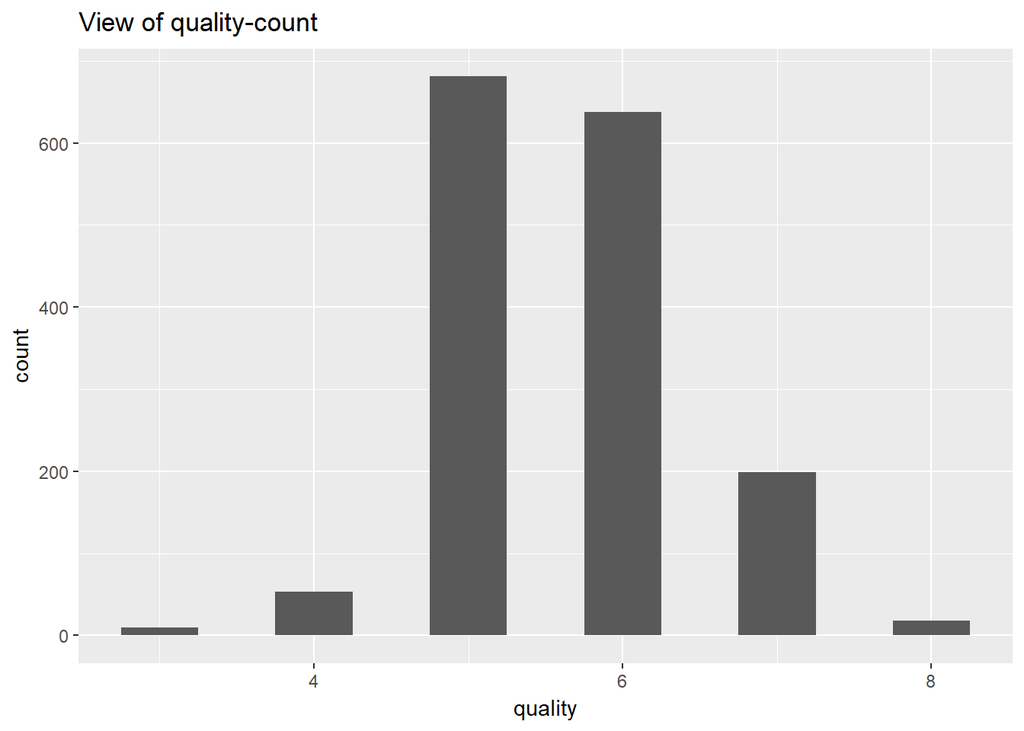

由图可知红酒的质量参数quality大部分评分为中等分数（5分，6分），好与差的分布都很少。

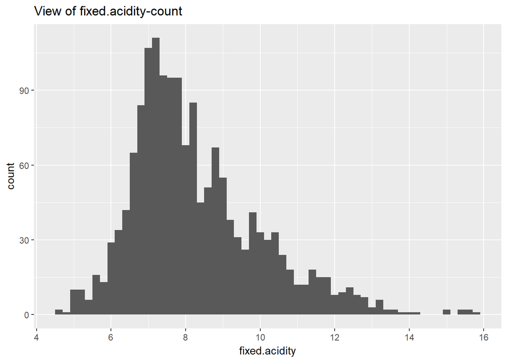

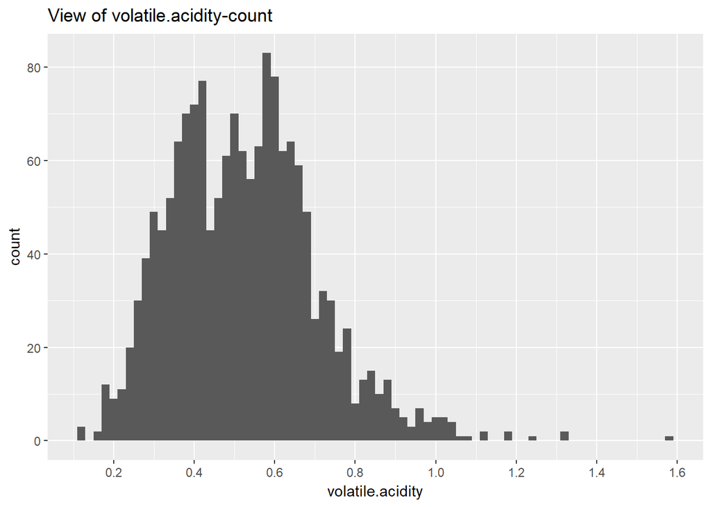

上图是挥发酸的浓度分布，绝大部分的红酒都位于0.2-1.0 g/dm^3。

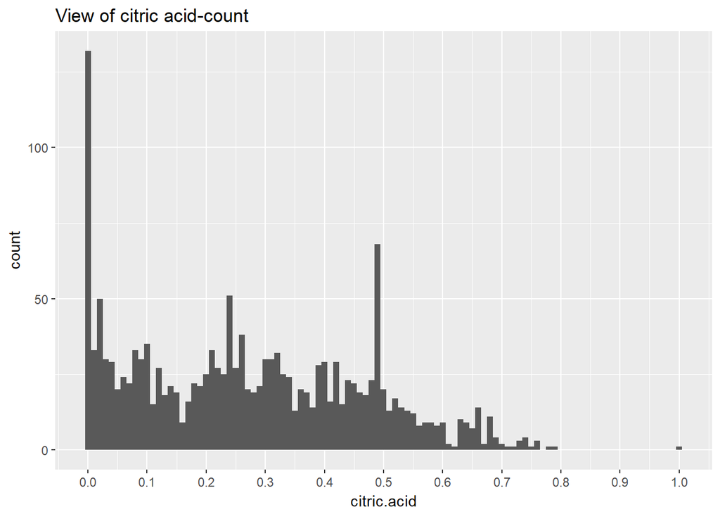

上图是柠檬酸的浓度分布，可以看到某些浓度的分布数量特别多，比如在0附近、0.25附近以及0.48附近的浓度值都具有很多的数量。其中取值是0的情况最多，表示很多红酒不含有柠檬酸。

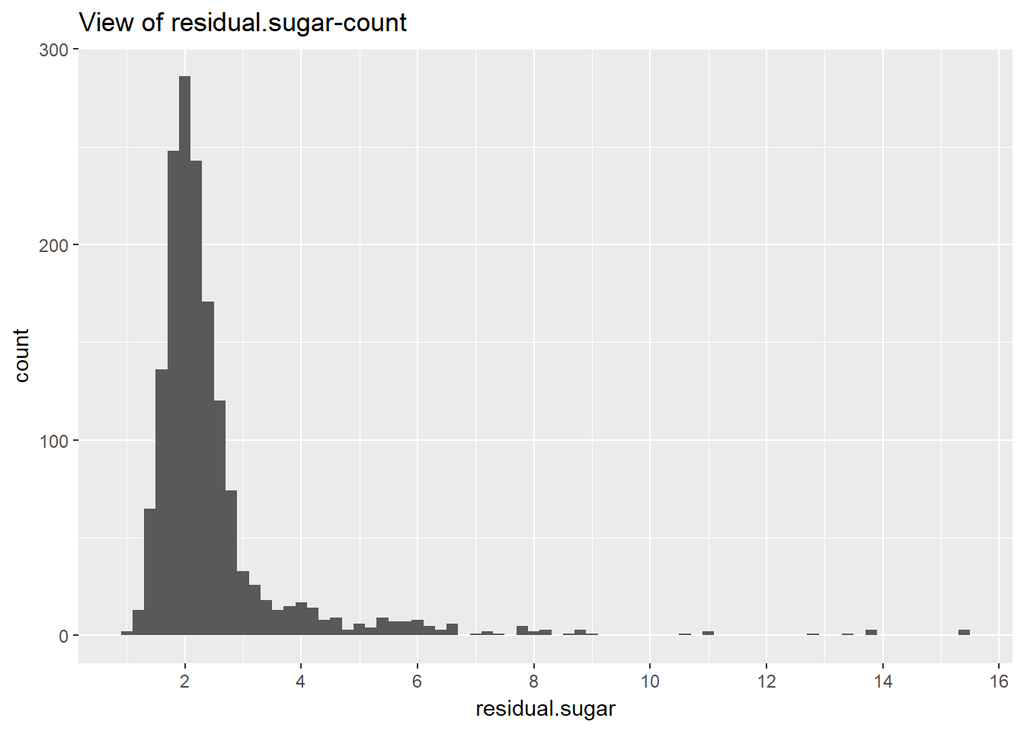

上图是残糖的浓度分布，可见大部分红酒的浓度聚集在0-6g/dm^3之间，且是长尾数据，考虑对浓度取对数重新作图：

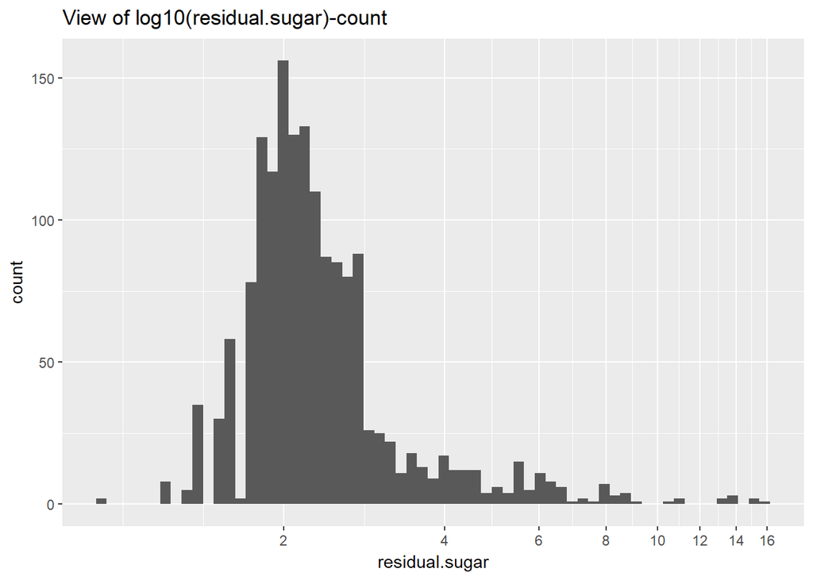

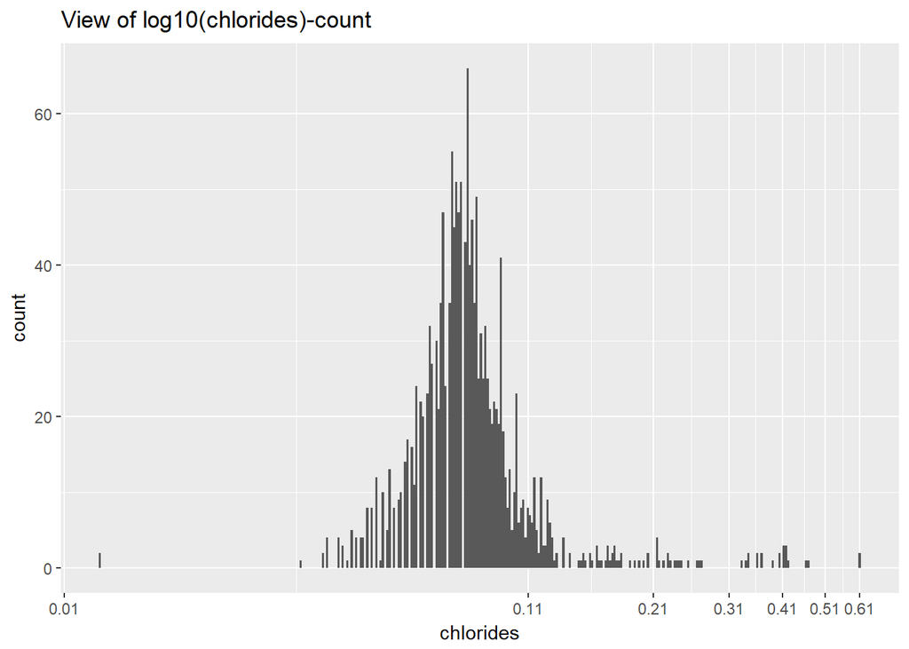

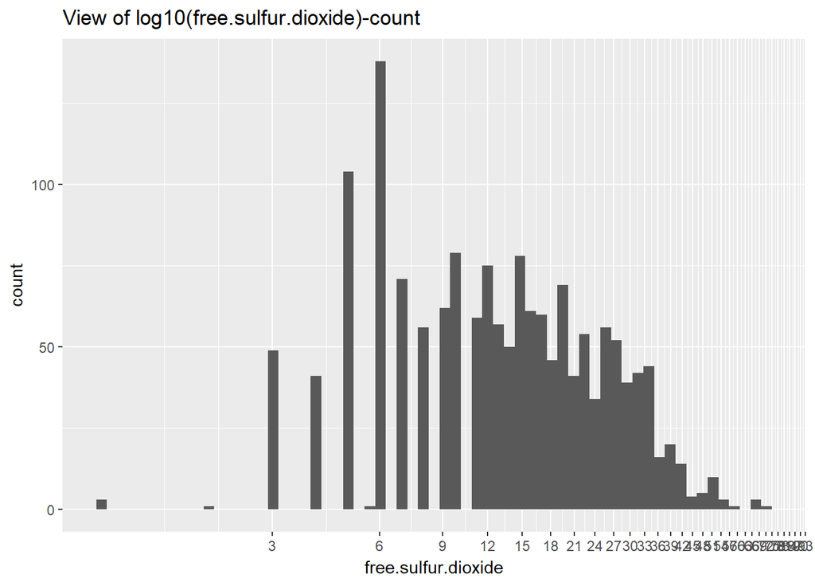

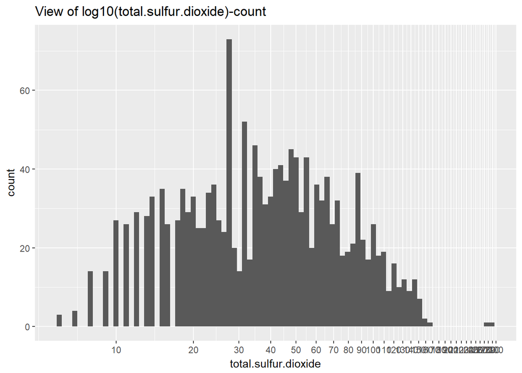

上图是总的二氧化硫量弄浓度分布，主要集中在10-150mg/dm^3。

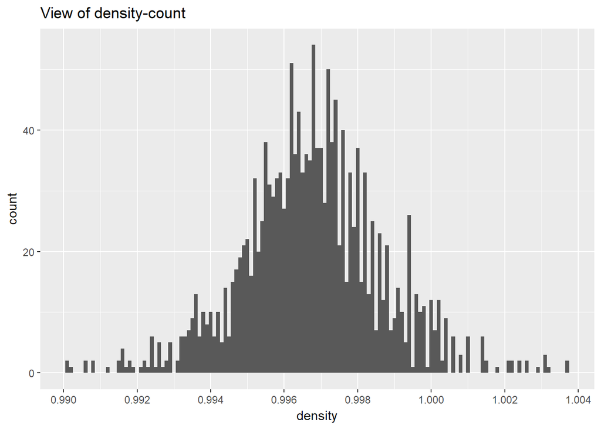

上图是密度分布图，其分布范围主要在0.993-1.001g/cm^3。

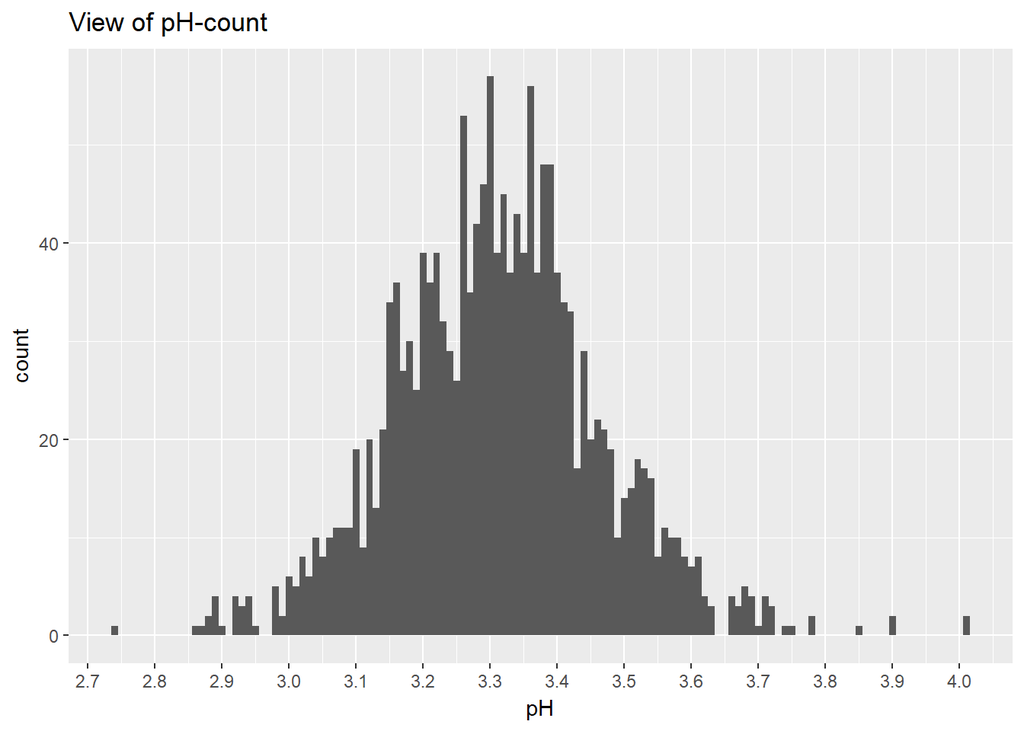

上图为酸度分布，可见红葡萄酒都是酸性，主要分布在Ph3.0-3.6的范围内。

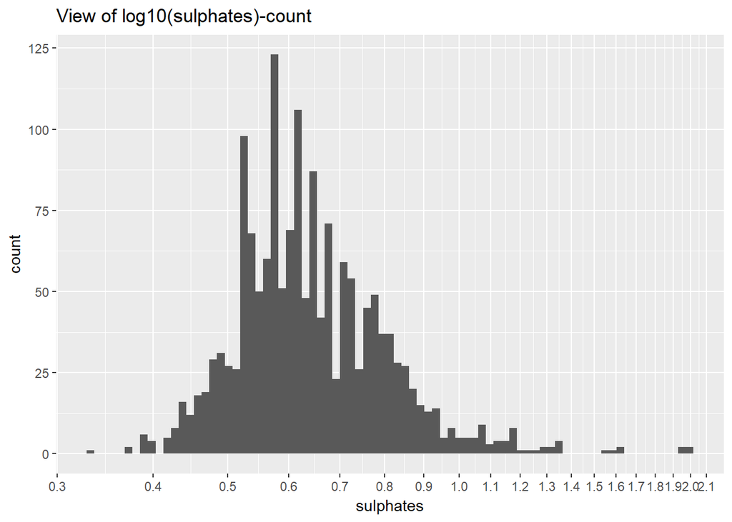

上图为硫酸盐分布，可见红葡萄酒都的硫酸盐主要分布在0.4-1.0g/dm^3的范围内。

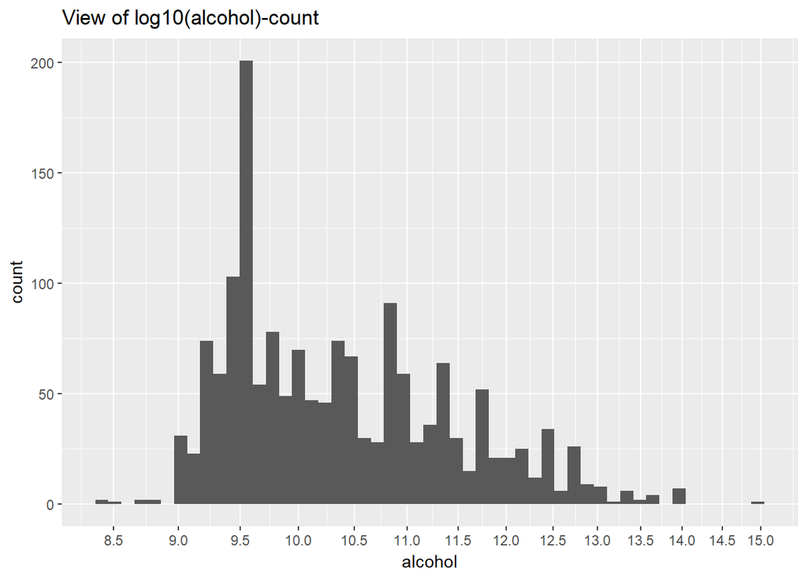

上图是酒精浓度分布，主要浓度范围为9%-13%，9.5%浓度具有最多的样本数量。

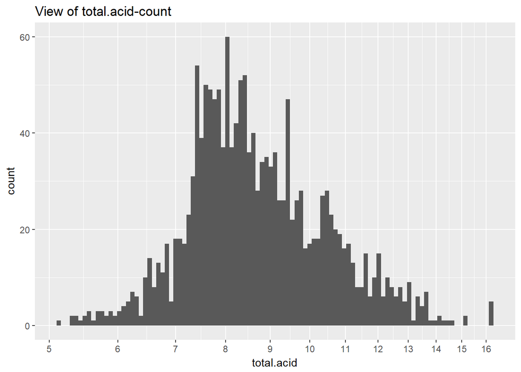

上图是总酸的分布，主要范围为6-14g/dm^3。

# 单变量分析

## 你的数据结构是什么？

```
红酒数据集包含1599个样本。除去一个x变量（id）, 12个特征参数为：fixed.acidity, volatile.acidity, citric.acid, residual.sugar, chlorides, free.sulfur.dioxide, total.sulfur.dioxide, density, pH, sulphates, alcohol, quality.
其中，quality为离散的整数类型，取值范围为[3, 8]，其他特征参数皆为浮点数。
```

## 你的数据集内感兴趣的主要特性有哪些？

```
我比较感兴趣红葡萄酒的品质值是否与酒精度数、柠檬酸、氯化物、pH值有关。
```

## 你认为数据集内哪些其他特征可以帮助你探索兴趣特点？

```
我认为酒的品质应该与入口口感与回味有关，因此重点关注会产生口感变化的特性，比如柠檬酸、残糖。
```

## 根据数据集内已有变量，你是否创建了任何新变量？

```
创建新变量总酸total.acid = fixed.acidity + volatile.acidity（非挥发性酸与挥发性酸的总浓度）
```

## 在已经探究的特性中，是否存在任何异常分布？你是否对数据进行一些操作，如清洁、调整或改变数据的形式？如果是，你为什么会这样做？

```
对于residual.sugar, chlorides, free.sulfur.dioxide, total.sulfur.dioxide, sulphates, alcohol等会变量，我在作图时对x轴进行了log10坐标变换。理由是这些数据的分布偏向长尾型数据，需要进行变换使主要部分靠近作图的中心部分。
```

# 双变量绘图

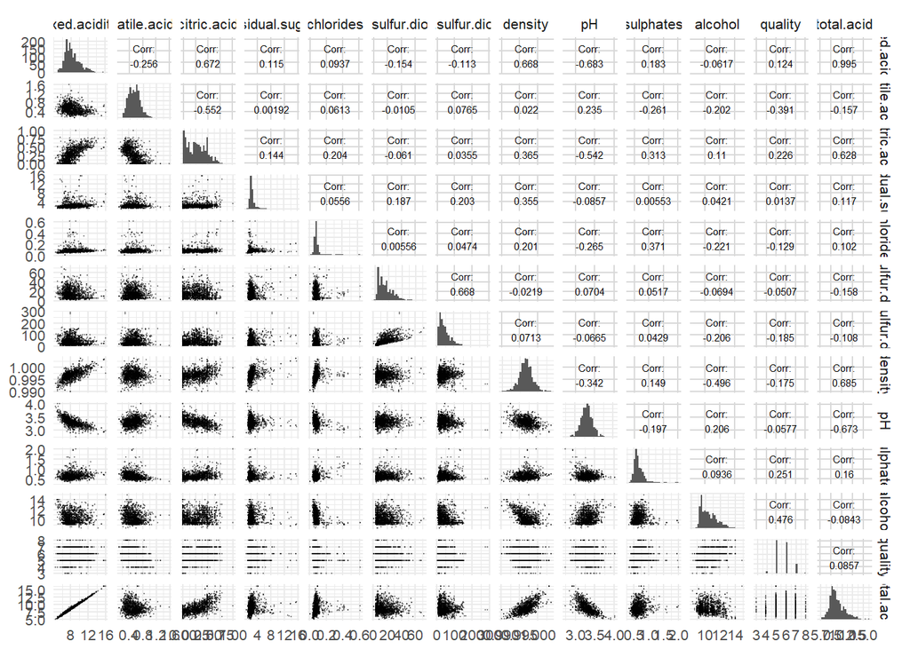

由图中可知，quanlity和其他特征的相关系数并没有特别高的：相关系数绝对值最高的是alcohol(0.476)，第二的是volatile.acidity(-0.391)，citric.acid与sulphates相关性系数都只有0.2左右；其他的特征相关系数都小于2。因此红葡萄酒的质量应该是由多个特征共同作用的。

## 酒精-品质图

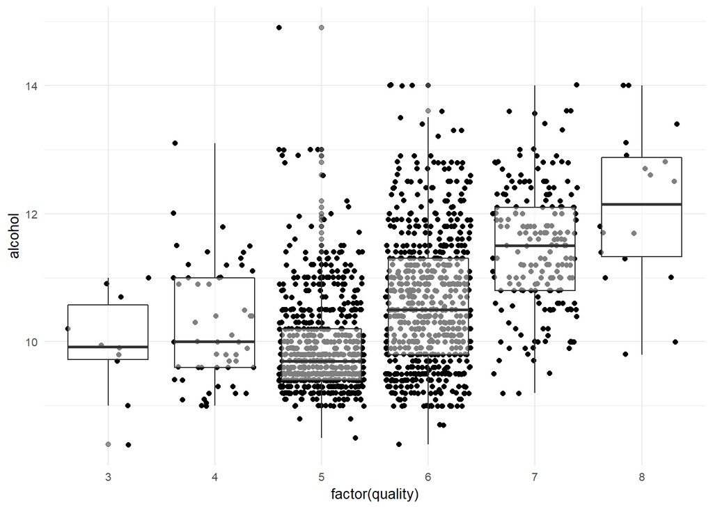

```
## wine_red_sub$quality: 3
##    Min. 1st Qu.  Median    Mean 3rd Qu.    Max.
##   8.400   9.725   9.925   9.955  10.575  11.000
## --------------------------------------------------------
## wine_red_sub$quality: 4
##    Min. 1st Qu.  Median    Mean 3rd Qu.    Max.
##    9.00    9.60   10.00   10.27   11.00   13.10
## --------------------------------------------------------
## wine_red_sub$quality: 5
##    Min. 1st Qu.  Median    Mean 3rd Qu.    Max.
##     8.5     9.4     9.7     9.9    10.2    14.9
## --------------------------------------------------------
## wine_red_sub$quality: 6
##    Min. 1st Qu.  Median    Mean 3rd Qu.    Max.
##    8.40    9.80   10.50   10.63   11.30   14.00
## --------------------------------------------------------
## wine_red_sub$quality: 7
##    Min. 1st Qu.  Median    Mean 3rd Qu.    Max.
##    9.20   10.80   11.50   11.47   12.10   14.00
## --------------------------------------------------------
## wine_red_sub$quality: 8
##    Min. 1st Qu.  Median    Mean 3rd Qu.    Max.
##    9.80   11.32   12.15   12.09   12.88   14.00
```

```
##
##  Pearson's product-moment correlation
##
## data:  wine_red_sub$alcohol and wine_red_sub$quality
## t = 21.639, df = 1597, p-value < 2.2e-16
## alternative hypothesis: true correlation is not equal to 0
## 95 percent confidence interval:
##  0.4373540 0.5132081
## sample estimates:
##       cor
## 0.4761663
```

相关性计算可知，酒精浓度与品质呈正相关。

## 挥发酸-品质图

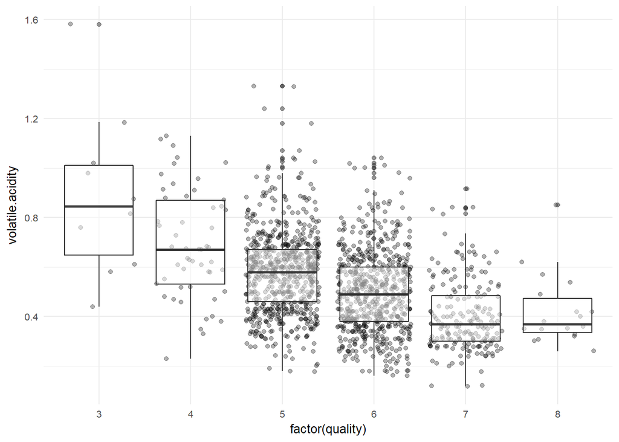

```
## wine_red_sub$quality: 3
##    Min. 1st Qu.  Median    Mean 3rd Qu.    Max.
##  0.4400  0.6475  0.8450  0.8845  1.0100  1.5800
## --------------------------------------------------------
## wine_red_sub$quality: 4
##    Min. 1st Qu.  Median    Mean 3rd Qu.    Max.
##   0.230   0.530   0.670   0.694   0.870   1.130
## --------------------------------------------------------
## wine_red_sub$quality: 5
##    Min. 1st Qu.  Median    Mean 3rd Qu.    Max.
##   0.180   0.460   0.580   0.577   0.670   1.330
## --------------------------------------------------------
## wine_red_sub$quality: 6
##    Min. 1st Qu.  Median    Mean 3rd Qu.    Max.
##  0.1600  0.3800  0.4900  0.4975  0.6000  1.0400
## --------------------------------------------------------
## wine_red_sub$quality: 7
##    Min. 1st Qu.  Median    Mean 3rd Qu.    Max.
##  0.1200  0.3000  0.3700  0.4039  0.4850  0.9150
## --------------------------------------------------------
## wine_red_sub$quality: 8
##    Min. 1st Qu.  Median    Mean 3rd Qu.    Max.
##  0.2600  0.3350  0.3700  0.4233  0.4725  0.8500
```

```
##
##  Pearson's product-moment correlation
##
## data:  wine_red_sub$volatile.acidity and wine_red_sub$quality
## t = -16.954, df = 1597, p-value < 2.2e-16
## alternative hypothesis: true correlation is not equal to 0
## 95 percent confidence interval:
##  -0.4313210 -0.3482032
## sample estimates:
##        cor
## -0.3905578
```

相关性计算可知，挥发酸与品质呈现负相关。

## 柠檬酸-品质图

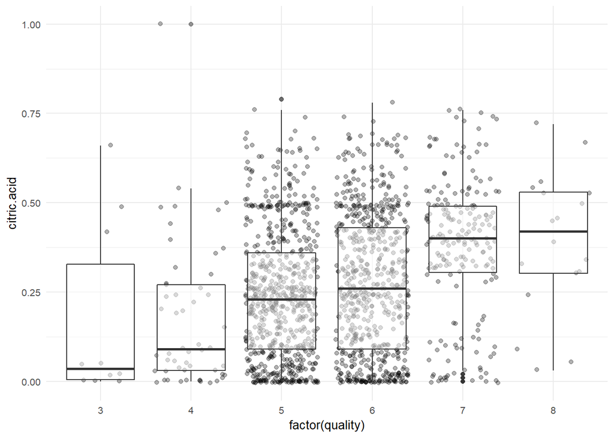

可以看出，品质越高的酒，其柠檬酸中位数浓度也越高。

```
##
##  Pearson's product-moment correlation
##
## data:  wine_red_sub$citric.acid and wine_red_sub$quality
## t = 9.2875, df = 1597, p-value < 2.2e-16
## alternative hypothesis: true correlation is not equal to 0
## 95 percent confidence interval:
##  0.1793415 0.2723711
## sample estimates:
##       cor
## 0.2263725
```

相关系数的计算结果确认有相关性，但是不明显。

## 硫酸盐-品质图

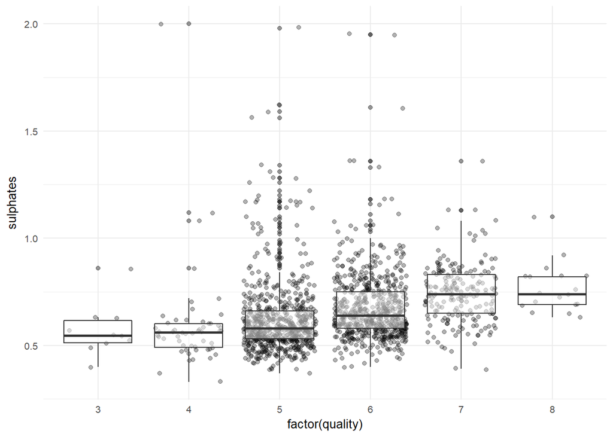

可以看出，品质越高的酒，其硫酸盐中位数浓度也越高。

```
##
##  Pearson's product-moment correlation
##
## data:  wine_red_sub$sulphates and wine_red_sub$quality
## t = 10.38, df = 1597, p-value < 2.2e-16
## alternative hypothesis: true correlation is not equal to 0
## 95 percent confidence interval:
##  0.2049011 0.2967610
## sample estimates:
##       cor
## 0.2513971
```

相关系数的计算结果确认有相关性，但是不明显。

## total.acid-品质图

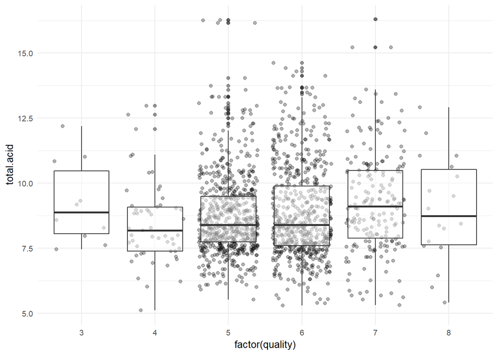

由上图可以看出，红酒各品质的总酸中位数相差不大。

```
##
##  Pearson's product-moment correlation
##
## data:  wine_red_sub$total.acid and wine_red_sub$quality
## t = 3.4378, df = 1597, p-value = 0.0006015
## alternative hypothesis: true correlation is not equal to 0
## 95 percent confidence interval:
##  0.03684298 0.13416675
## sample estimates:
##        cor
## 0.08570932
```

```
## wine_red_sub$quality: 3
##    Min. 1st Qu.  Median    Mean 3rd Qu.    Max.
##   7.460   8.051   8.883   9.245  10.460  12.180
## --------------------------------------------------------
## wine_red_sub$quality: 4
##    Min. 1st Qu.  Median    Mean 3rd Qu.    Max.
##   5.120   7.380   8.185   8.473   9.070  12.960
## --------------------------------------------------------
## wine_red_sub$quality: 5
##    Min. 1st Qu.  Median    Mean 3rd Qu.    Max.
##   5.520   7.735   8.390   8.744   9.490  16.260
## --------------------------------------------------------
## wine_red_sub$quality: 6
##    Min. 1st Qu.  Median    Mean 3rd Qu.    Max.
##   5.300   7.605   8.400   8.845   9.881  14.610
## --------------------------------------------------------
## wine_red_sub$quality: 7
##    Min. 1st Qu.  Median    Mean 3rd Qu.    Max.
##   5.320   7.880   9.110   9.276  10.485  16.285
## --------------------------------------------------------
## wine_red_sub$quality: 8
##    Min. 1st Qu.  Median    Mean 3rd Qu.    Max.
##   5.420   7.625   8.730   8.990  10.530  12.910
```

相关系数计算也可以得出，总酸与品质相关性很低。

## density-fixed.acidity图

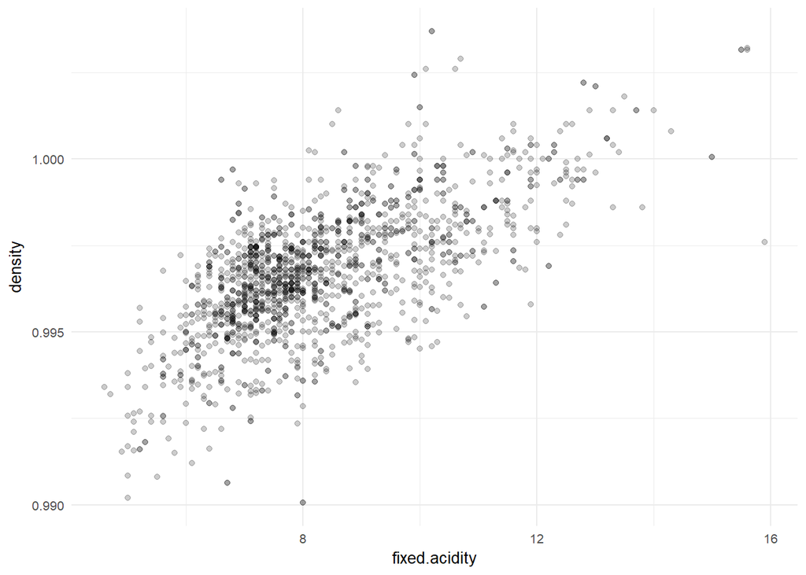

```
##
##  Pearson's product-moment correlation
##
## data:  wine_red_sub$density and wine_red_sub$fixed.acidity
## t = 35.877, df = 1597, p-value < 2.2e-16
## alternative hypothesis: true correlation is not equal to 0
## 95 percent confidence interval:
##  0.6399847 0.6943302
## sample estimates:
##       cor
## 0.6680473
```

可以看出，红酒的密度与非挥发性酸相关性很大，说明红酒中非挥发性酸类物质含量较多。

## fixed.acidity-pH图

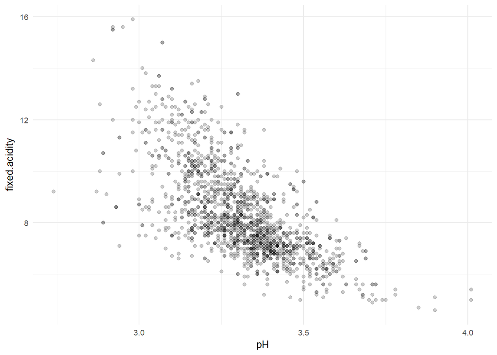

可见非挥发性酸浓度越高，红酒的越趋于酸性。

```
##
##  Pearson's product-moment correlation
##
## data:  wine_red_sub$fixed.acidity and wine_red_sub$pH
## t = -37.366, df = 1597, p-value < 2.2e-16
## alternative hypothesis: true correlation is not equal to 0
## 95 percent confidence interval:
##  -0.7082857 -0.6559174
## sample estimates:
##        cor
## -0.6829782
```

可见非挥发性酸浓度越高对红酒的酸性起了很大作用。

# 双变量分析

## 你是否观察到主要特性与其他特性之间的有趣关系？

1.密度与非挥发性酸相关性较大。 2.pH与非挥发性酸相关性较大。

## 你发现最强的关系是什么？

最强的相关性是pH与非挥发性酸，相关系数为-0.683

# 多变量绘图

## sulphates-fixed.acidity-pH作图

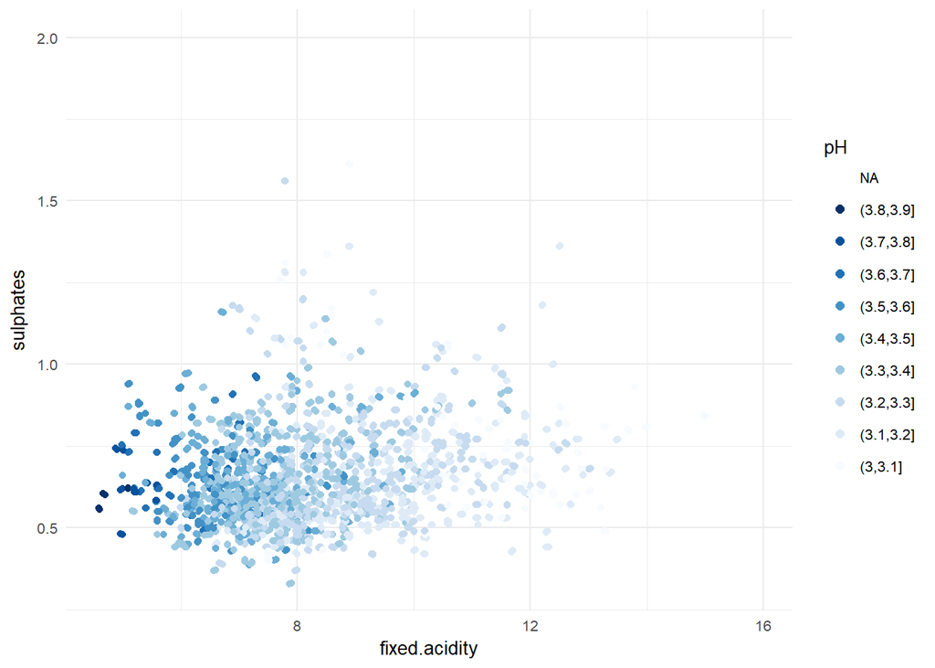

由图可见，硫酸盐浓度一定时，非挥发酸浓度越高，pH值越低。

## quality-volatile.acidity-alcohol作图

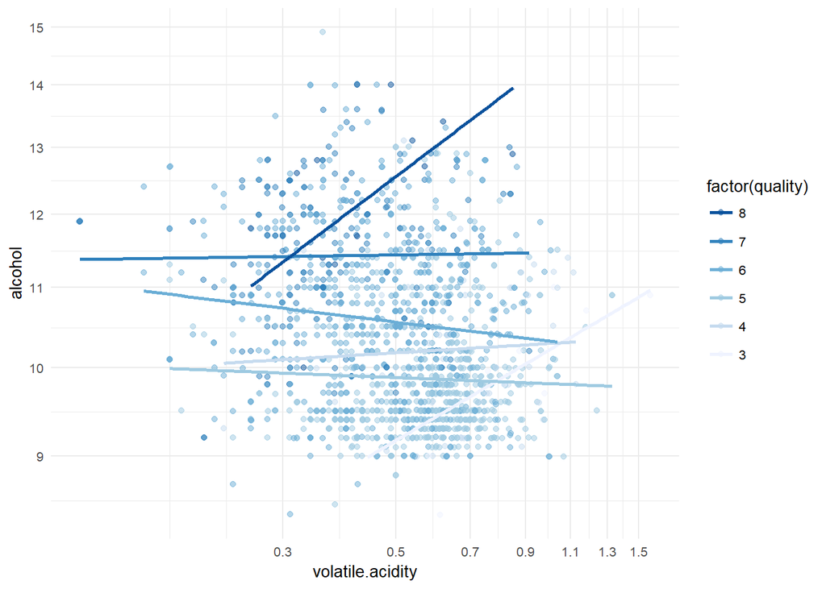

从图中可以看到，如果一瓶红酒具有较高的酒精含量（大于11%）与较低的挥发酸含量(小于0.8)，则有更大的可能是高品质酒。

## density-pH-alcohol作图

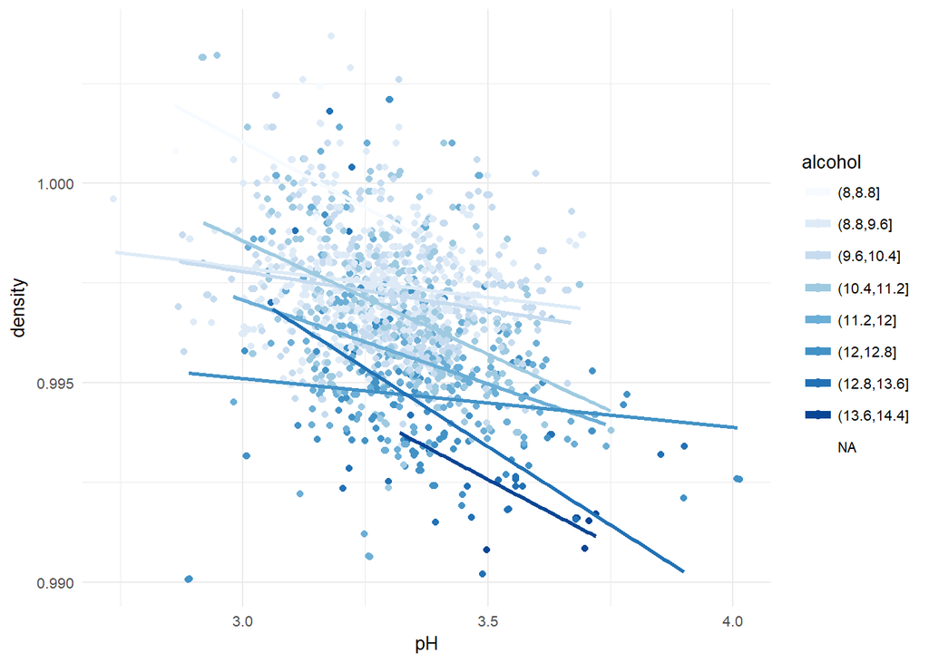

从图中可以看出，pH越大、密度越小，酒精浓度就越高；pH越低、密度越大、酒精浓度越低。

## 线性模型拟合

```
##
## Calls:
## m1: lm(formula = quality ~ volatile.acidity, data = wine_red_sub)
## m2: lm(formula = quality ~ volatile.acidity + alcohol, data = wine_red_sub)
## m3: lm(formula = quality ~ volatile.acidity + alcohol + sulphates,
##     data = wine_red_sub)
## m4: lm(formula = quality ~ volatile.acidity + alcohol + sulphates +
##     total.sulfur.dioxide, data = wine_red_sub)
##
## ================================================================================
##                              m1            m2            m3            m4
## --------------------------------------------------------------------------------
##   (Intercept)               6.566***      3.095***      2.611***      2.826***
##                            (0.058)       (0.184)       (0.196)       (0.201)
##   volatile.acidity         -1.761***     -1.384***     -1.221***     -1.199***
##                            (0.104)       (0.095)       (0.097)       (0.097)
##   alcohol                                 0.314***      0.309***      0.295***
##                                          (0.016)       (0.016)       (0.016)
##   sulphates                                             0.679***      0.712***
##                                                        (0.101)       (0.101)
##   total.sulfur.dioxide                                               -0.002***
##                                                                      (0.001)
## --------------------------------------------------------------------------------
##   R-squared                 0.153         0.317         0.336         0.344
##   adj. R-squared            0.152         0.316         0.335         0.342
##   sigma                     0.744         0.668         0.659         0.655
##   F                       287.444       370.379       268.912       208.768
##   p                         0.000         0.000         0.000         0.000
##   Log-likelihood        -1794.312     -1621.814     -1599.384     -1589.835
##   Deviance                883.198       711.796       692.105       683.887
##   AIC                    3594.624      3251.628      3208.768      3191.669
##   BIC                    3610.756      3273.136      3235.654      3223.932
##   N                      1599          1599          1599          1599
## ================================================================================
```

选取相关性系数较大的几个特征进行建模，发现建模后的拟合度不如预期，R-squared仅为0.344

# 多变量分析

## 探讨你在这部分探究中观察到的一些关系。通过观察感兴趣的特性，是否存在相互促进的特性？

1.硫酸盐浓度一定时，非挥发酸浓度越高，pH值越低。 2.pH越大、密度越小，酒精浓度就越高；pH越低、密度越大、酒精浓度越低。

## 选项：你是否创建过数据集的任何模型？讨论你模型的优缺点。

我创建的模型准确度不够，推测可能需要对某些特征进行非线性处理。

# 定稿图与总结

## 绘图1

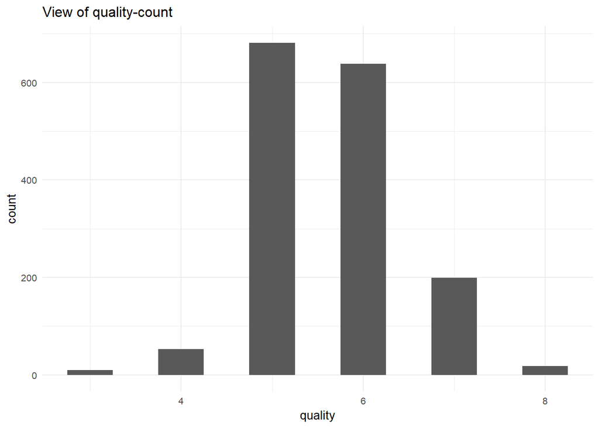

## 描述1

quality的分布图是单峰形态，大部分取值为5-6分，很差与很好的数量都很少。

## 绘图2

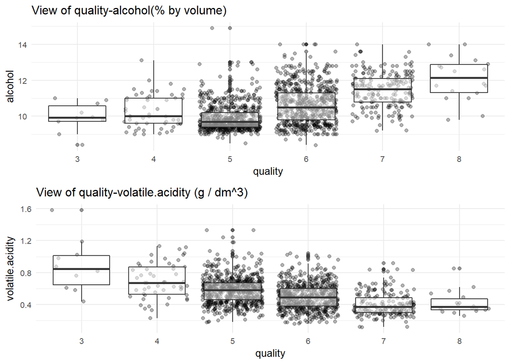

## 绘图3

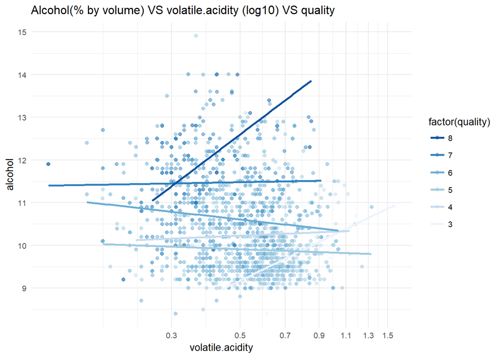

## 描述3

从图中可以看到，如果一瓶红酒具有较高的酒精含量（大于11%）与较低的挥发酸含量(小于0.8)，则有更大的可能是高品质酒。

# 反思

由于这是我第一次进行数据分析EDA，所以对于作图等R语言的语法与特性不是很熟悉，花了很多时间在函数测试与帮助文档阅读上；对于分析目标的不清晰也导致中间走了一些弯路。最终的获得的经验是，一定要在开始的时候确定目标，并规划好后续分析展开时的工作重点，这样才不会浪费过多时间在非核心分析上。对于建模部分，此次报告中的模型效果较差，以后还需要多多学习相关分析与建模知识,使模型能够更好拟合数据。